# Supplement S8: Comparing model results with existing surveys

# 1 Preamble

This is an Electronic Supplement to the manuscript Marques et al. “Quantifying Deepwater Horizon oil spill induced injury on pelagic cetaceans” published in Marine Ecology Progress Series.

There are 8 Electronic Supplements to the paper. The master file containing links to all the other 7 additional Electronic Supplements related to this paper is Supplement_S1.

You might be reading this file as a pdf or as an html. If you reading this file as a pdf distributed as an Electronic Supplement to the MEPS paper, the links will not work. The links on this file only work if:

1. you are using the html version of it, available via the https://github.com/TiagoAMarques/CARMMHApapersSI, or
2. if you compiled it yourself as html and you have all the 8 html files in the same folder.

## 1.1 Version history

This section details the version history for static pdf files submitted as Electronic Supplement pdfs:

- 1.0 [12 Aug 2022] Version included as a pdf Electronic Supplement in the MEPS original submission
- 2.0 [10 Feb 2023] Version included as a pdf Electronic Supplement in the MEPS re-submission after 1st round of reviewer’s comments
- 3.0 [26 May 2023] Version with all file names renamed to match requirements by editorial team at MEPS

Given MEPS’s Supplements correspond to static files, readers might want to check if there are any new file versions or added materials at the project github repository: The source .Rmd files are provided in the github repository:

https://github.com/TiagoAMarques/CARMMHApapersSI # Introduction

Here we provide a comparison of the abundance estimates from our simulation models a few years after the oil spill with independent abundance estimates for the different taxonomic units.

There were surveys from 2003, 2004 and 2009, which we averaged and consider to be representative of pre-spill abundance, and then there are surveys from 2017 and 2018, which again we averaged and assume to represent 8 years post oil spill abundance.

We then compare the reduction in population size between these survey-based empirical estimates vs the reduction observed in our simulations.

Details about the code used to produce the plots below is available in the corresponding “.Rmd” file (“ES7_ComparingWithSurveys.Rmd”).

# 2 The survey data

The survey data are taken out of Garrison et al. (2020, 2021), and were compiled in a .xlsx document also provided under the “InputFiles” folder. The file name is “GOMMAPS_ABUNDANCE_ESTIMATES.xlsx”

Some surveys are for a pair of years, and we first recodes these, for visual display purposes, as a single year value, corresponding to the the mid point between those successive years.

The original data file did not include the 4 letter code we considered in general for each taxonomic unit on the remaining documents. Therefore, we first define the rows corresponding to each taxonomic unit via their corresponding 4 letter code.

# 3 Comparisons by taxonomic unit

Next, we produce, for each species, a plot including the abundance point estimates given the considered surveys. Further, we compute for each species the change in population size from before to after 2010, based on surveys. We refer to these as observed, noting the name is somewhat misleading since they are not really observed but estimated from empirical data, but that will contract to what we will refer to as expected, based on our simulations. We compare, on a taxonomic by taxonomic unit basis, the observed reduction with the expected reduction.

## 3.1 Beaked whales

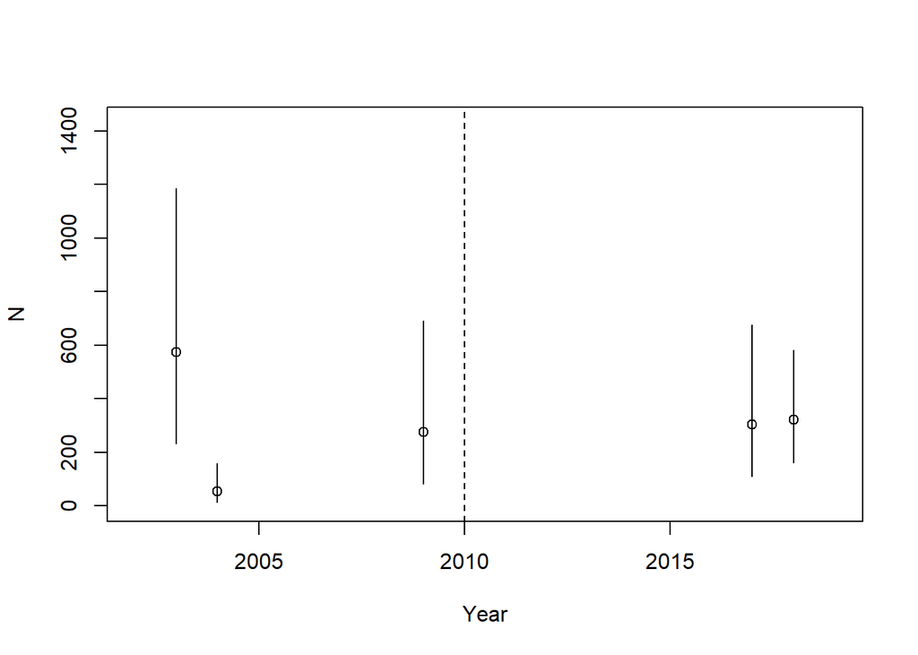

We can calculate the reduction from before to after, generating means from before and after

Therefore, given the surveys, there was actually an increase in the abundance of beaked whales in the area of 1.151, with a 95% confidence interval of (0.454,2.435). This means there is large uncertainty over what was the evolution of the population, which could have been anywhere from a severe decrease to a large increase.

On the other hand, based on our simulations, we obtain the following reduction factor: 0.967, with a 95% confidence interval of (0.938,0.988). A comparison of these mean values and corresponding 95% confidence intervals is shown in the figure below. Values above the horizontal line actually correspond to population increases.

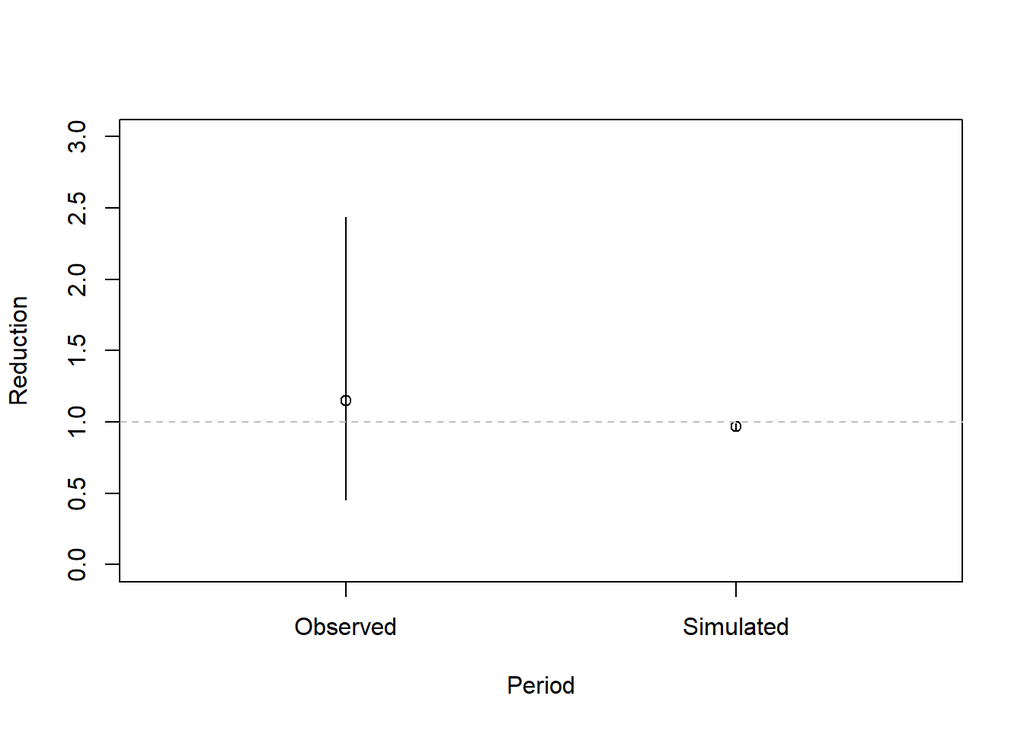

While the reduction factor based on the empirical data from the surveys and that from the simulations are not inconsistent, the truth is the precision associated with these, most especially the large variance in the survey data, would not allow us to find anything but astronomical differences.

## 3.2 Pygmy killer whale $Feresa~attenuata$

We can calculate the reduction from before to after, generating means from before and after

Therefore, given the surveys, there was actually an increase in the abundance of beaked whales in the area of 1.152, with a 95% confidence interval of (0.454,2.437). This means there is large uncertainty over what was the evolution of the population, which could have been anywhere from a severe decrease to a large increase.

On the other hand, based on our simulations, we obtain the following reduction factor: 0.961, with a 95% confidence interval of (0.936,0.982). A comparison of these mean values and corresponding 95% confidence intervals is shown in the figure below.

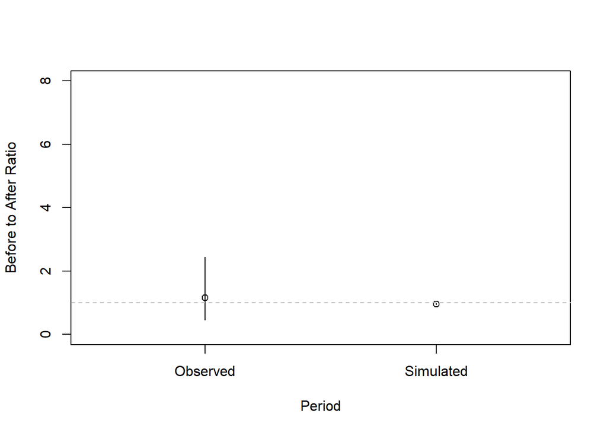

While the reduction factor based on the empirical data from the surveys and that from the simulations are not inconsistent, the truth is the precision associated with these, most especially the large variance in the survey data, would not allow us to find anything but astronomical differences.

## 3.3 Risso’s dolphin $Grampus~griseus$

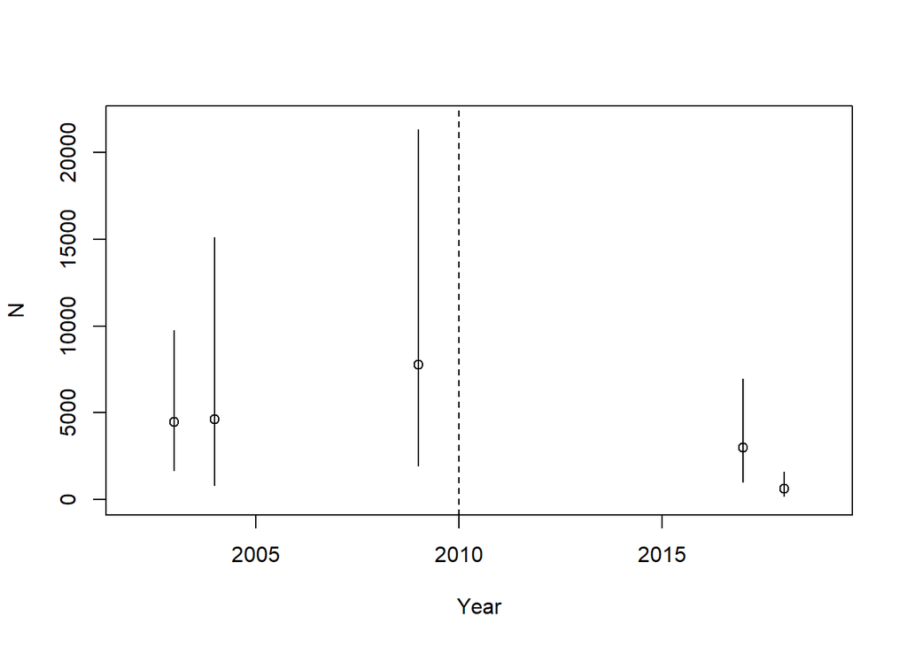

We can calculate the reduction from before to after, generating means from before and after

Based on the surveys there seems to have been a decrease on the abundance of Rissos’s dolphin of 0.371, 95% confidence interval of (0.106,0.951).

On the other hand, based on our simulations, we obtain the following reduction factor: 0.946, with a 95% confidence interval of (0.908,0.976). A comparison of these mean values and corresponding 95% confidence intervals is shown in the figure below.

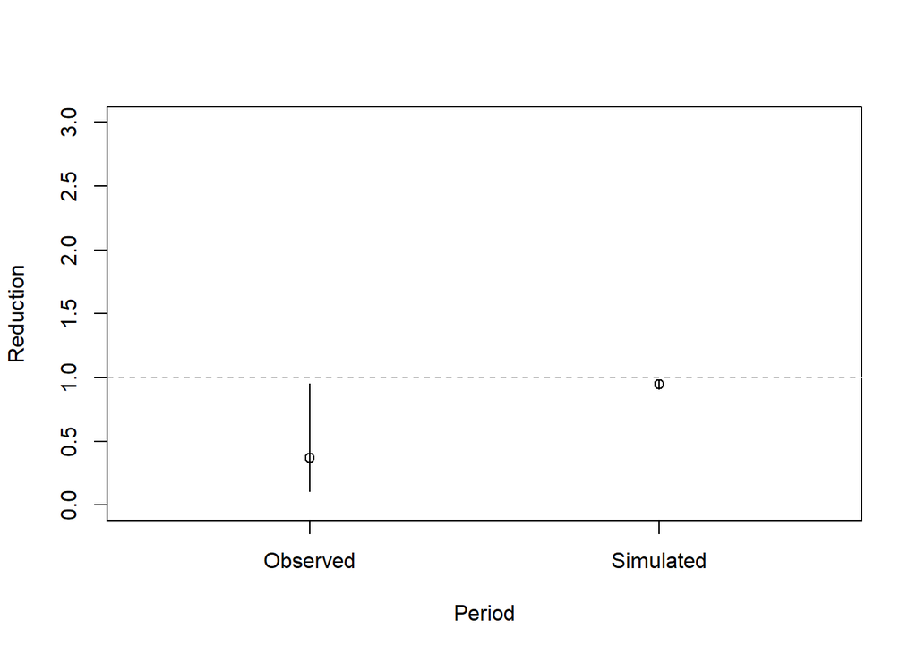

The reduction factors based on the empirical data from the surveys and that from the simulations are not inconsistent.

## 3.4 Short-finned pilot whale $Globicephala~macrorhynchus$

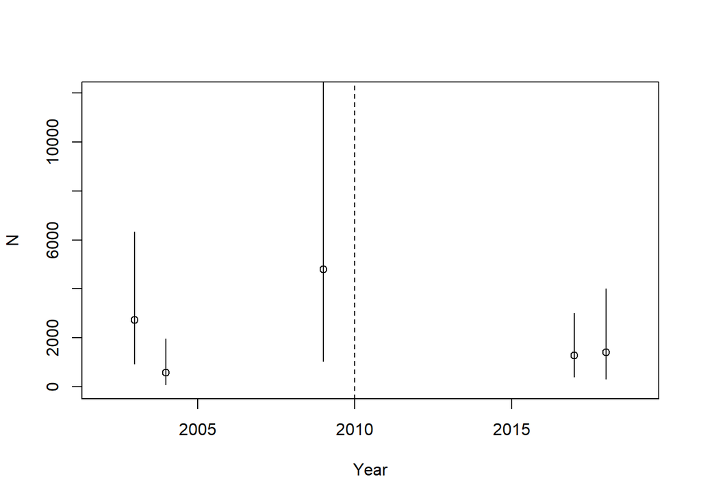

We can calculate the reduction from before to after, generating means from before and after

Based on the surveys there seems to have been a decrease on the abundance of pilot whales of 0.592, 95% confidence interval of (0.152,1.582).

On the other hand, based on our simulations, we obtain the following reduction factor: 0.967, with a 95% confidence interval of (0.94,0.986). A comparison of these mean values and corresponding 95% confidence intervals is shown in the figure below. Values above the horizontal line actually correspond to population increases.

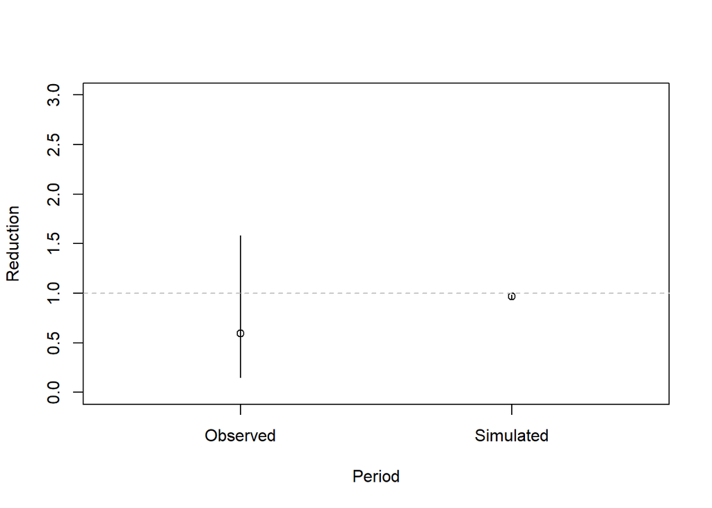

While the reduction factor based on the empirical data from the surveys and that from the simulations are not inconsistent, the truth is the precision associated with these, most especially the large variance in the survey data, would not allow us to find anything but astronomical differences.

## 3.5 Kogia spp.

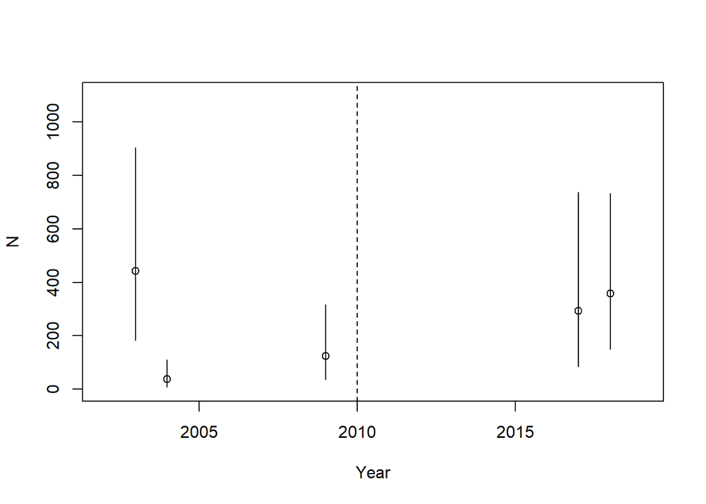

We can calculate the reduction from before to after, generating means from before and after

Based on the surveys there seems to have been an increase on the abundance of Kogia whales of 1.797, 95% confidence interval of (0.64,4.035).

On the other hand, based on our simulations, we obtain the following reduction factor: 0.954, with a 95% confidence interval of (0.92,0.98). A comparison of these mean values and corresponding 95% confidence intervals is shown in the figure below.

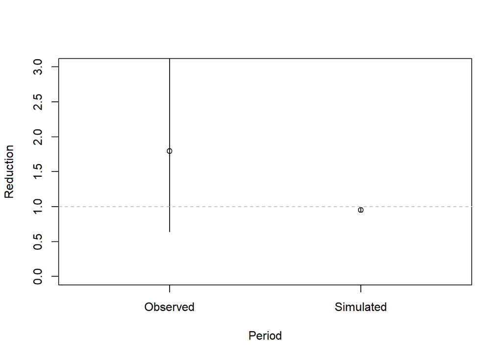

The reduction factors based on the empirical data from the surveys and that from the simulations are not inconsistent.

## 3.6 Melon-headed whale $Peponocephala~electra$

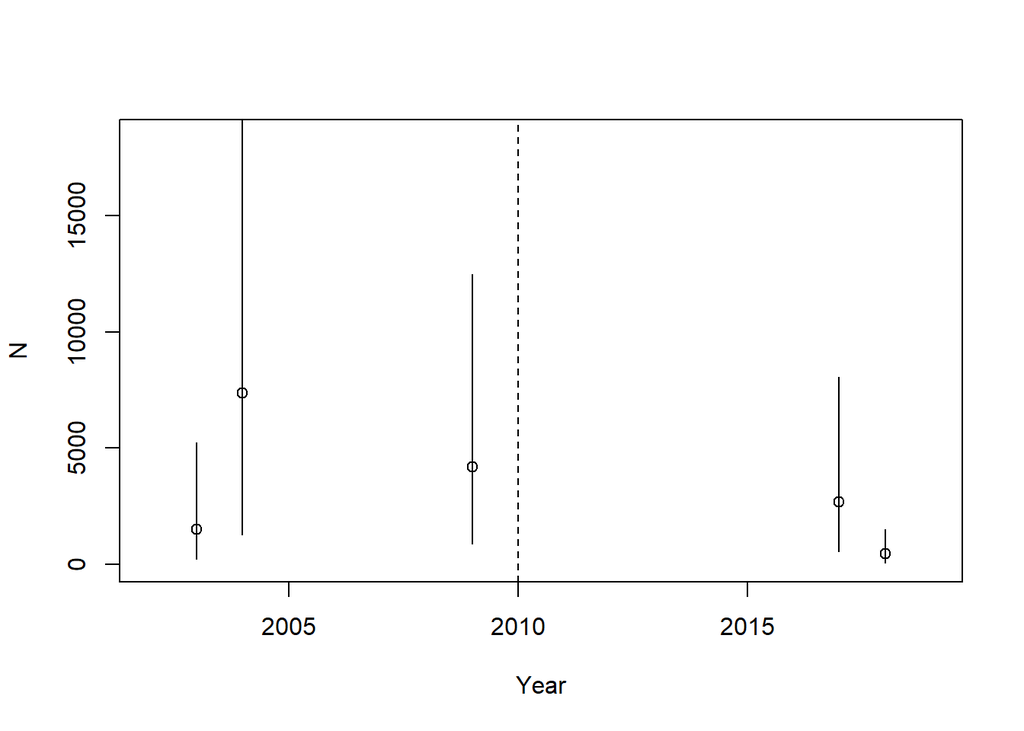

We can calculate the reduction from before to after, generating means from before and after

Based on the surveys there seems to have been a decrease on the abundance of Kogia whales of 0.462, 95% confidence interval of (0.078,1.549).

On the other hand, based on our simulations, we obtain the following reduction factor: 0.962, with a 95% confidence interval of (0.937,0.983). A comparison of these mean values and corresponding 95% confidence intervals is shown in the figure below.

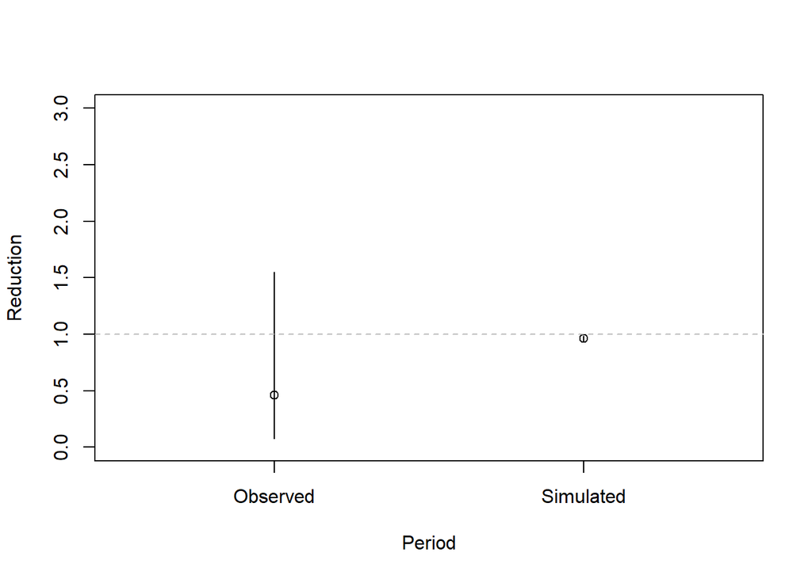

The reduction factors based on the empirical data from the surveys and that from the simulations are not inconsistent.

## 3.7 Sperm whale $Physeter~macrocephalus$

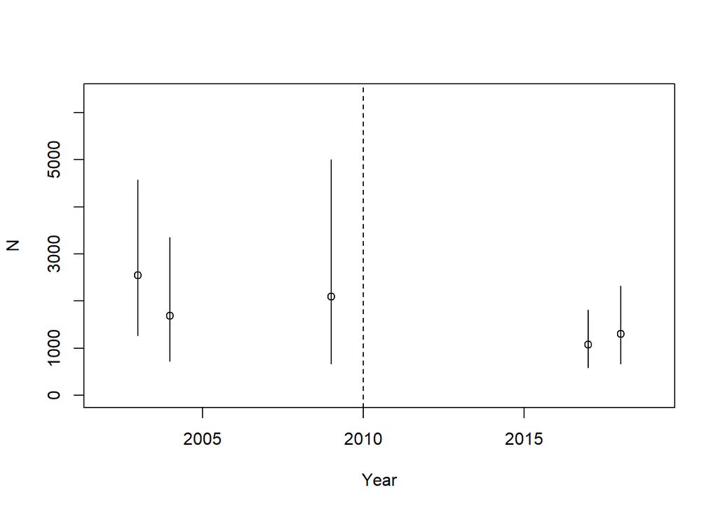

We can calculate the reduction from before to after, generating means from before and after

Based on the surveys there seems to have been a decrease on the abundance of Kogia whales of 0.6, 95% confidence interval of (0.298,1.077).

On the other hand, based on our simulations, we obtain the following reduction factor: 0.94, with a 95% confidence interval of (0.902,0.974). A comparison of these mean values and corresponding 95% confidence intervals is shown in the figure below.

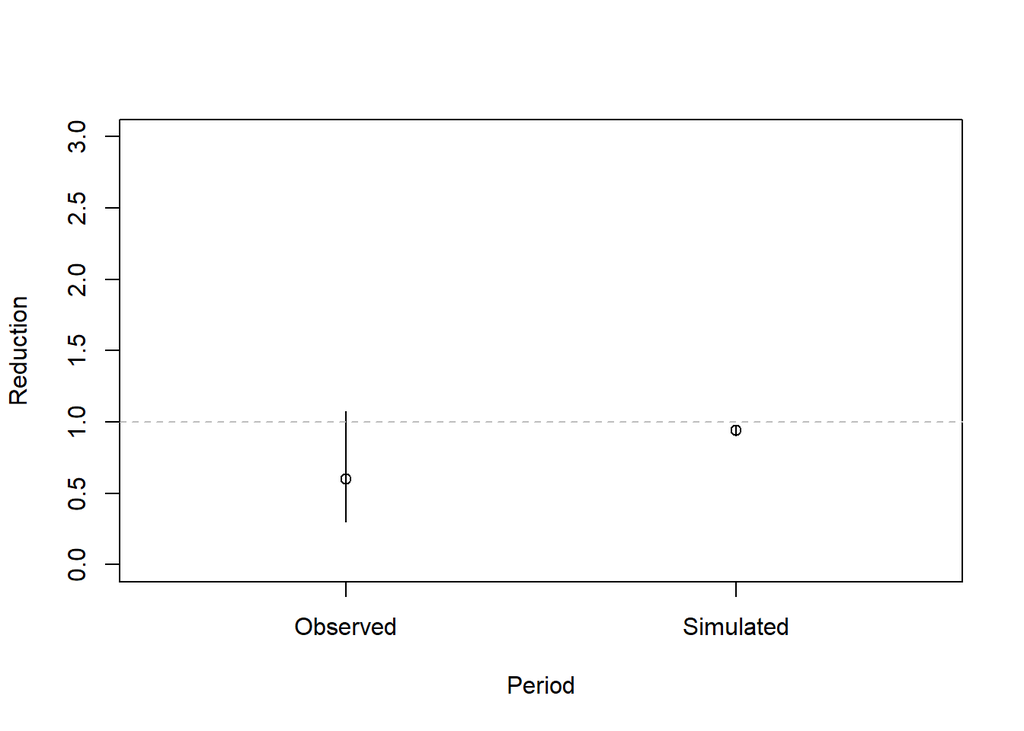

The reduction factors based on the empirical data from the surveys and that from the simulations are not inconsistent.

## 3.8 Pantropical spotted dolphin $Stenella~attenuata$

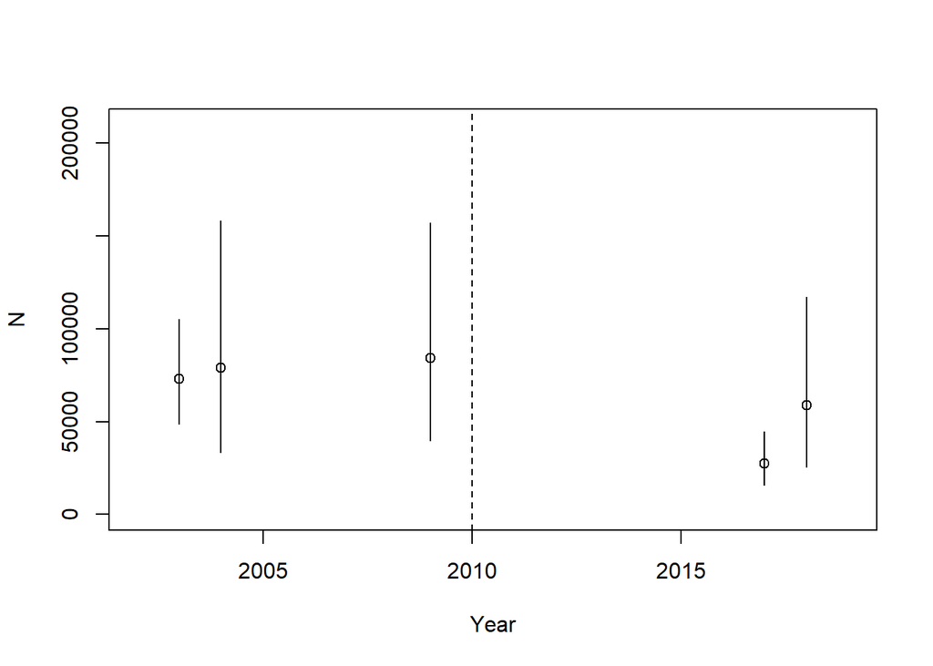

We can calculate the reduction from before to after, generating means from before and after

Based on the surveys there seems to have been a decrease on the abundance of Kogia whales of 0.568, 95% confidence interval of (0.28,1.053).

On the other hand, based on our simulations, we obtain the following reduction factor: 0.969, with a 95% confidence interval of (0.947,0.987). A comparison of these mean values and corresponding 95% confidence intervals is shown in the figure below.

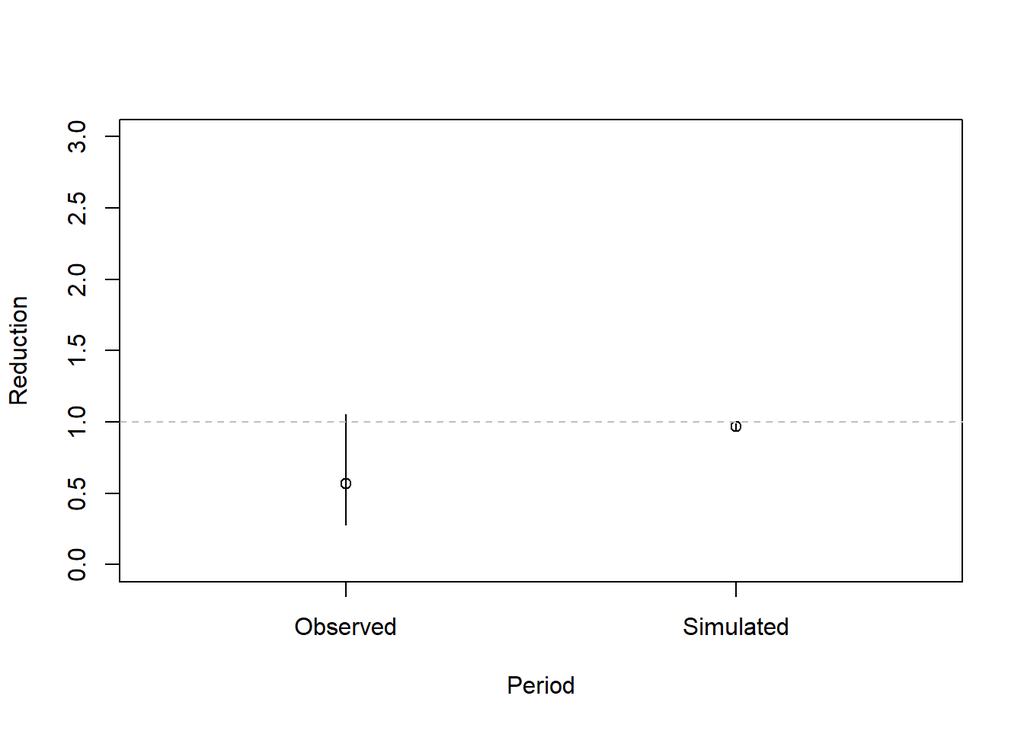

The reduction factors based on the empirical data from the surveys and that from the simulations are not inconsistent.

## 3.9 Rough-toothed dolphin $Steno~bredanensis$

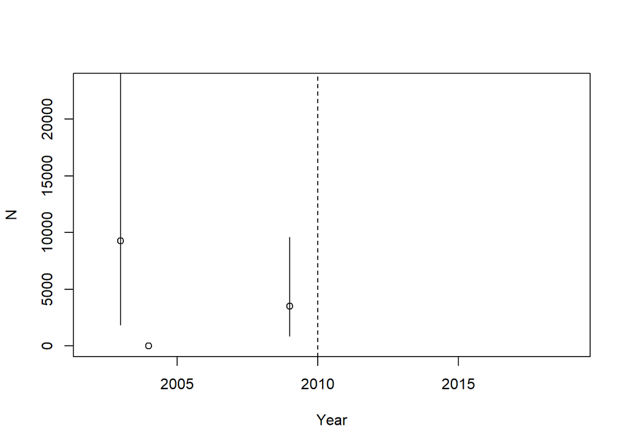

We do not present estimates of empirical reduction since there are no non-zero estimates for the post oil-spill period.

## 3.10 Clymene dolphin $Stenella~clymene$

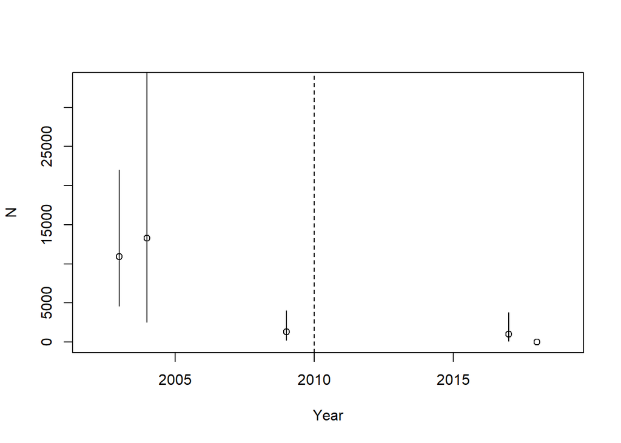

We can calculate the reduction from before to after, generating means from before and after

Based on the surveys there seems to have been a decrease on the abundance of Kogia whales of 0.071, 95% confidence interval of (0.007,0.287).

On the other hand, based on our simulations, we obtain the following reduction factor: 0.984, with a 95% confidence interval of (0.97,0.994). A comparison of these mean values and corresponding 95% confidence intervals is shown in the figure below.

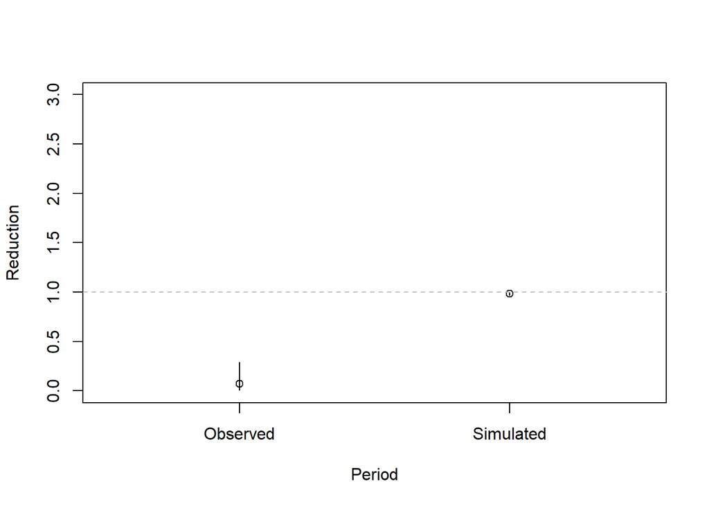

For the Clymene dolphin, the reduction factors estimated from the simulations seems to be considerably less severe than that observed empirically from the survey data.

## 3.11 Striped dolphin $Stenella~coeruleoalba$

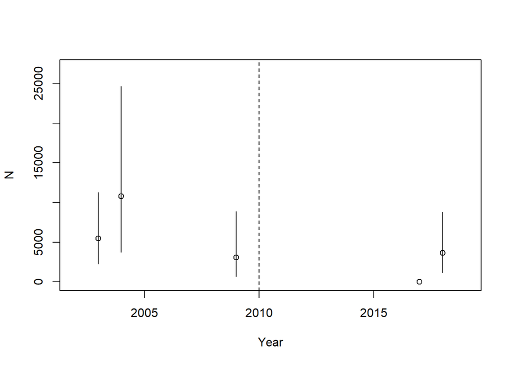

We can calculate the reduction from before to after, generating means from before and after

Based on the surveys there seems to have been a decrease on the abundance of Kogia whales of 0.311, 95% confidence interval of (0.078,0.849).

On the other hand, based on our simulations, we obtain the following reduction factor: 0.945, with a 95% confidence interval of (0.899,0.978). A comparison of these mean values and corresponding 95% confidence intervals is shown in the figure below.

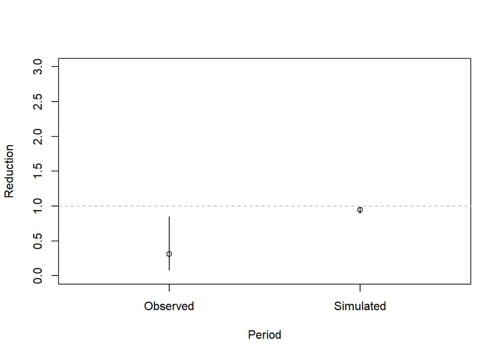

As for the Clymene dolphin, also for the striped dolphin the reduction factors estimated from the simulations seems to be considerably less severe than that observed empirically from the survey data.

## 3.12 Atlantic spotted dolphin $Stenella frontalis$

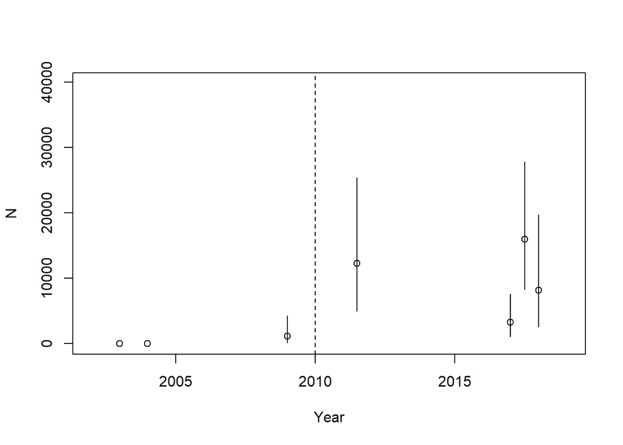

For these animals, the surveys in 2003, 2004, 2009, 2017 and 2018 were vessel surveys targeting oceanic animals, while in 2011-2012 and 2017-2018 there were aerial surveys targeting shelf animals. We ignored surveys before 2009, when the species was not detected. We assume that the surveys from the 2009 for oceanic summed summed with the 2011-2012 for shelf combined provide a best guess for the pre-spill population estimate, while the surveys for 2017 and 2018 for oceanic summed to those for 2017-2018 for shelf provide an estimate of the post spill population.

On the other hand, based on our simulations, we obtain the following reduction factor: 0.988, with a 95% confidence interval of (0.979,0.995). A comparison of these mean values and corresponding 95% confidence intervals is shown in the figure below.

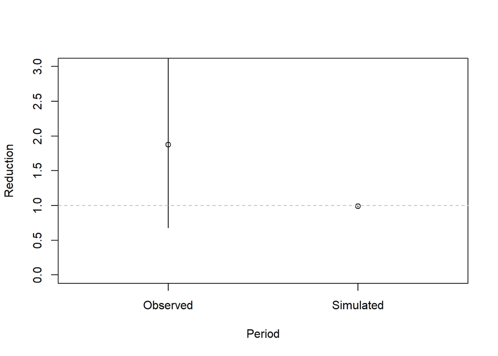

For the Atlantic spotted dolphin the wide variability in the survey reduction factor, with a point estimate even suggesting a population increase might have occurred, means the simulated reduction factor is not at odds with the empirical data.

## 3.13 Spinner dolphin $Stenella~longirostris$

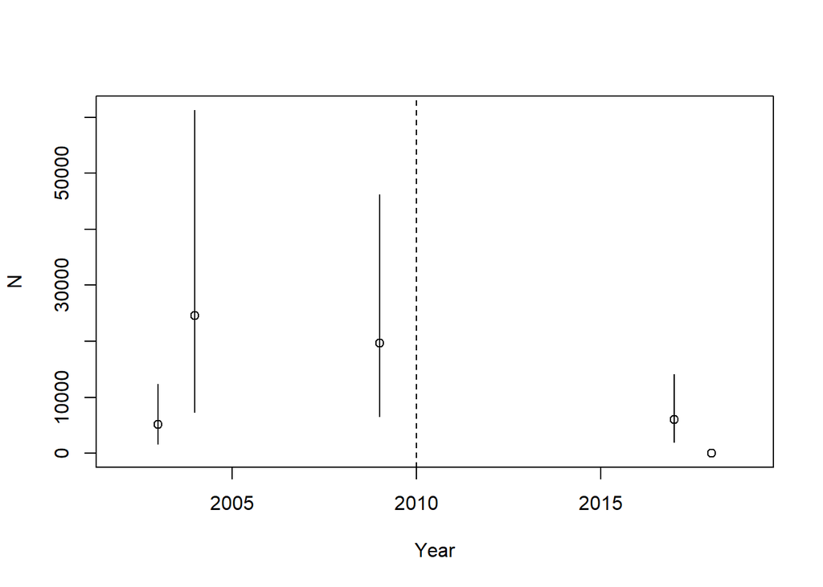

We can calculate the reduction from before to after, generating means from before and after

Based on the surveys there seems to have been a decrease on the abundance of spinner dolphin of 0.205, 95% confidence interval of (0.051,0.562).

On the other hand, based on our simulations, we obtain the following reduction factor: 0.917, with a 95% confidence interval of (0.827,0.972). A comparison of these mean values and corresponding 95% confidence intervals is shown in the figure below.

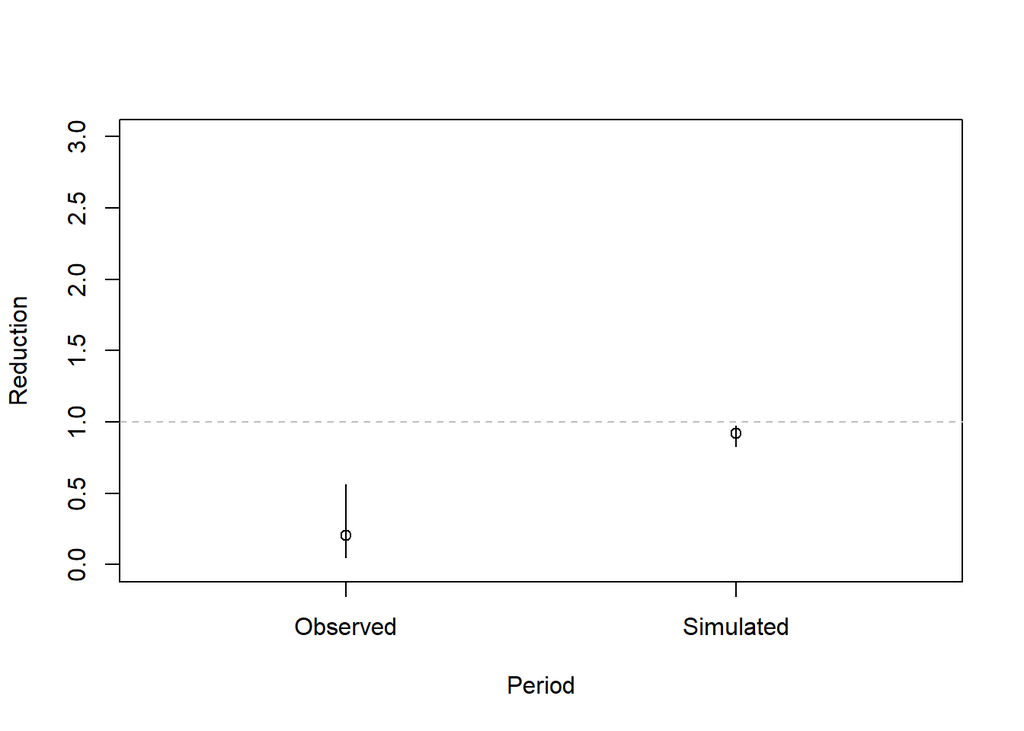

As for both the Clymene dolphin and the striped dolphin, for the spinner dolphin the reduction factors estimated from the simulations seem to be considerably less severe than that observed empirically from the survey data.

## 3.14 Bottlenose dolphin $Tursiops~truncatus$ (oceanic)

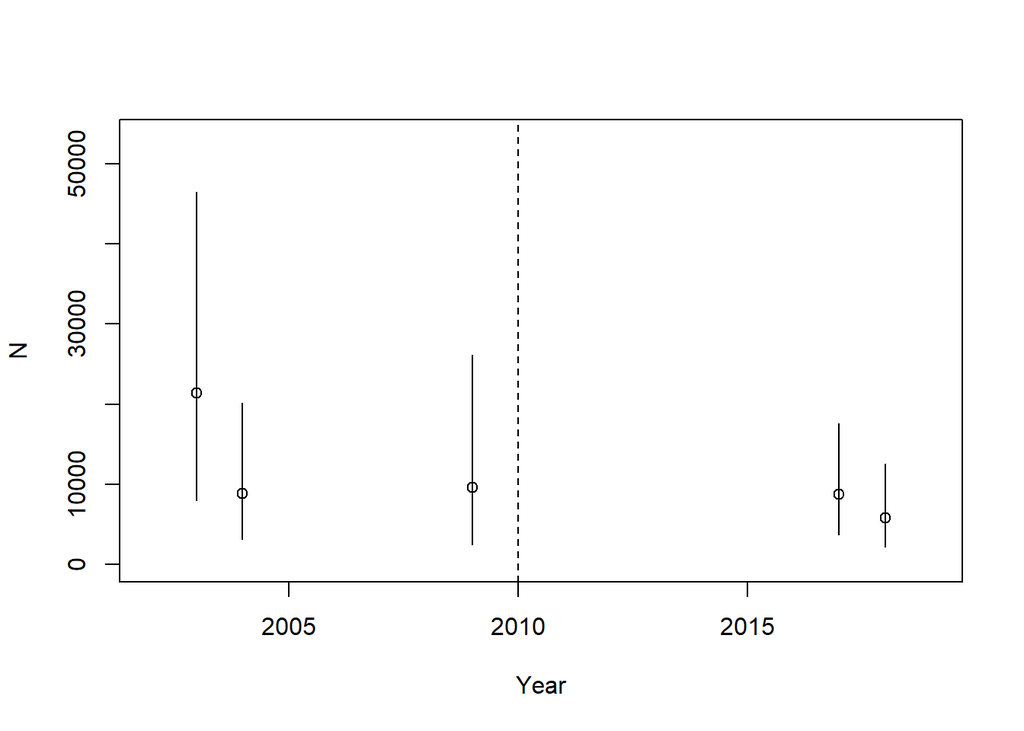

We can calculate the reduction from before to after, generating means from before and after

Based on the surveys there seems to have been a decrease on the abundance of Kogia whales of 0.604, 95% confidence interval of (0.236,1.275).

On the other hand, based on our simulations, we obtain the following reduction factor: 0.948, with a 95% confidence interval of (0.913,0.977). A comparison of these mean values and corresponding 95% confidence intervals is shown in the figure below.

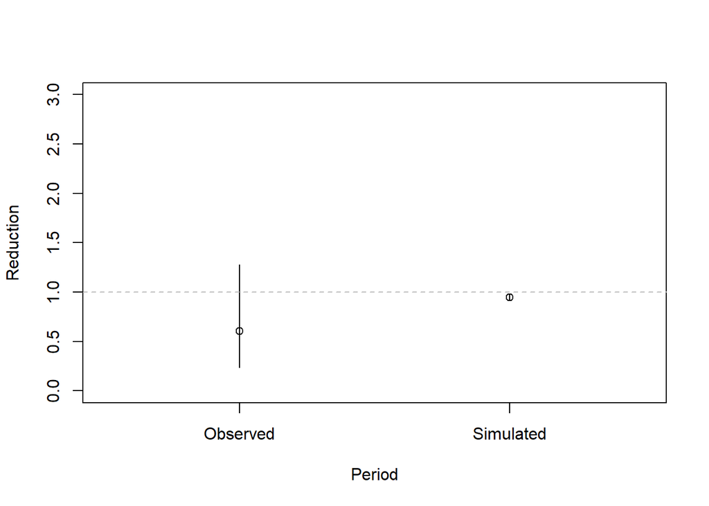

The reduction factors based on the empirical data from the surveys and that from the simulations are not inconsistent.

## 3.15 Bottlenose dolphin $Tursiops~truncatus$ (shelf)

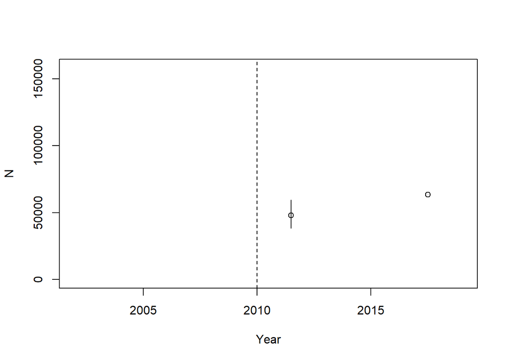

No direct comparison is possible since there were no estimates prior to the oil-spill.

# 4 References

- Garrison, Lance P., Ortega-Ortiz, Joel,Rappucci, Gina (2020) Abundance of Marine Mammals in Waters of the U.S. Gulf of Mexico During the Summers of 2017 and 2018. National Marine Fisheries Service.;Southeast Fisheries Science Center. Southeast Fisheries Science Center reference document PRBD 2020-07. https://doi.org/10.25923/3px6-9v48
- Garrison, Lance P., Ortega-Ortiz, Joel, Rappucci, Gina (2021) Abundance of Coastal and Continental Shelf Stocks of Common Bottlenose and Atlantic Spotted Dolphins in the Northern Gulf of Mexico: 2017-2018, National Marine Fisheries Service.;Southeast Fisheries Science Center. Southeast Fisheries Science Center reference document PRBD 2021-01. https://doi.org/10.25923/vk95-t881